# Hutter Prize Problem

## Problem Statement

The Hutter Prize Problem has to do with compressing a 100mb file containing a multitude of wikipedia pages. These pages contain all of the data from the wikipedia pages including the html/meta information. The current best is 16mb, and according to Shannon's estimations the Hutter Prize File should be theoretically compressable to around 12mb.

## Data Exploration

The data comes in as a large file containing all of the pages in one large file. We should load the data in and see what needs to be done.

```python
from requests import get
from zipfile import ZipFile
from io import BytesIO
from os import path
from IPython.display import display

%matplotlib inline

hutter_url = 'http://mattmahoney.net/dc/enwik8.zip'
root_dir = '.'
data_root = path.join(root_dir, 'raw_data')
data_path = path.join(data_root, 'enwik8')

hutter_r = get(hutter_url)
zipper = ZipFile(BytesIO(hutter_r.content))
zipper.extractall(data_root)

content = None
with open(data_path) as data:
    content = data.read()
```

### Variable Length Coding?

One characteristic of the data that might be important is the probability distibution of the data. Using Huffman Coding it's possible to get increases in compression just by representing high probability characters with a shorter length code.

```python
from collections import Counter
import numpy as np

char_counts = Counter(list(content))
display(char_counts.most_common(10))
```

```
[(' ', 13519824),
 ('e', 8001205),
 ('t', 6154908),
 ('a', 5712026),
 ('i', 5227649),
 ('o', 5176143),
 ('n', 4909103),
 ('r', 4506880),
 ('s', 4347421),
 ('l', 3047318)]
```

#### Log Transformation

Because of the size of the numbers, I am going to do a logarithmic transformation of the numbers.

```python
char_freq = np.array(list(char_counts.values()))
num_chars = sum(char_freq)
char_rel_freq = char_freq / num_chars

char_rel_freq_log = np.log10(char_rel_freq)
```

Now that we have counts of all the characters we should graph the probability distribution.

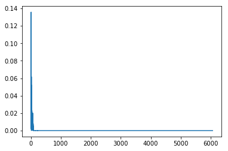

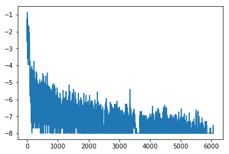

```python
import matplotlib.pyplot as plt

plt.plot(char_rel_freq)
plt.figure()
plt.plot(char_rel_freq_log)
```

It appears the the characters have a skewed probability distribution.